# Ejercicio de PCA vs KPCA

*Aprendizaje máquina II*

*Curso 2023-2024*

Authors:

- Rubén Castillo Carrasco

- Manuel Rubio Martínez

# PCA vs Kernel PCA

```python
#NumPy: numerical scientific computing
import numpy as np

#Scikit-learn: machine learning
from sklearn import datasets
from sklearn.decomposition import PCA, KernelPCA

#Matplotlib: plotting
import matplotlib.pyplot as plt
%matplotlib inline
#%matplotlib notebook
```

```python
# Definimos una función para comparar los parámetros de la Kernel PCA

def Params_KPCA(X = X, kernel = "rbf", gamma = 15, degree = 3):
    #Transformaciones PCA y KPCA
    X_pca = PCA().fit_transform(X)

    kpca = KernelPCA(kernel= kernel, gamma = gamma, degree = degree ,fit_inverse_transform=True).fit(X)

    X_kpca = kpca.transform(X)
    X_back = kpca.inverse_transform(X_kpca)

    #Representacion datos transformados
    reds = y == 0
    blues = y == 1
    plt.figure()

    plt.subplot(2, 2, 1, aspect='equal')
    plt.plot(X[reds, 0], X[reds, 1], "ro")
    plt.plot(X[blues, 0], X[blues, 1], "bo")
    plt.title("Original space")
    plt.xlabel("$x_1$")
    plt.ylabel("$x_2$")

    plt.subplot(2, 2, 2, aspect='equal')
    plt.plot(X_pca[reds, 0], X_pca[reds, 1], "ro")
    plt.plot(X_pca[blues, 0], X_pca[blues, 1], "bo")
    plt.title("Projection by PCA")
    plt.xlabel("1st principal component")
    plt.ylabel("2nd component")

    plt.subplot(2, 2, 3, aspect='equal')
    plt.plot(X_kpca[reds, 0], X_kpca[reds, 1], "ro")
    plt.plot(X_kpca[blues, 0], X_kpca[blues, 1], "bo")
    plt.title("Projection by KPCA")
    plt.xlabel("1st principal component in space induced by $\phi$")
    plt.ylabel("2nd component")

    plt.subplot(2, 2, 4, aspect='equal')
    plt.plot(X_back[reds, 0], X_back[reds, 1], "ro")
    plt.plot(X_back[blues, 0], X_back[blues, 1], "bo")
    plt.title("Original space after inverse transform")
    plt.xlabel("$x_1$")
    plt.ylabel("$x_2$")

    plt.subplots_adjust(0.05, 0.05, 0.95, 0.95, 0.5, 0.5)

    plt.show()
```

### Qué representa el valor de gamma en un kernel RBF y cuál sería el valor de gamma óptimo?

El gamma indica hasta cuánto de lejos afectan las distancias para el kernel en el espacio transformado. Gammas bajas indican que aunque estén muy lejos unas de otras se siguen influyendo, y servirá para conjuntos de datos más dispersos, y gammas más altas se utilizarán para problemas de clusterización con subconjuntos de datos más concentrados.

## Moons:

```python
#Generacion datos
#np.random.seed(0)
X, y = datasets.make_moons(n_samples=500, random_state=77) #10 100 500
```

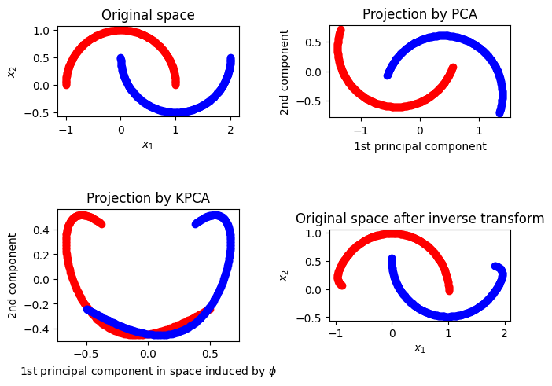

```python
Params_KPCA(X = X, kernel = "rbf", gamma = 1)
```

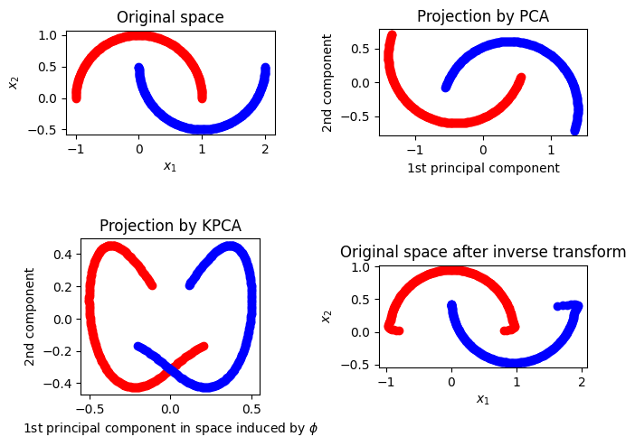

```python
Params_KPCA(X = X, kernel = "rbf", gamma = 5)
```

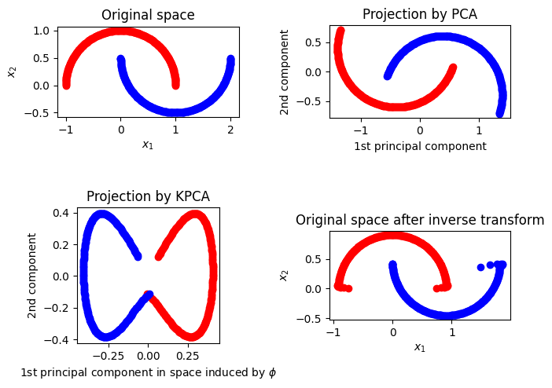

```python
Params_KPCA(X = X, kernel = "rbf", gamma = 10)
```

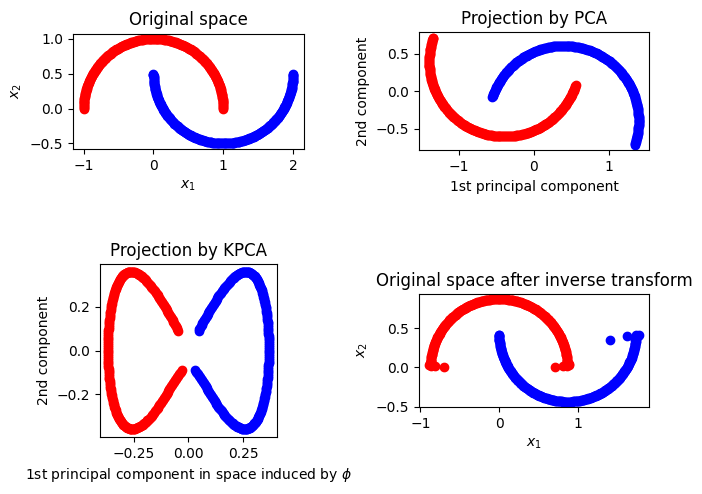

```python
Params_KPCA(X = X, kernel = "rbf", gamma = 15)
```

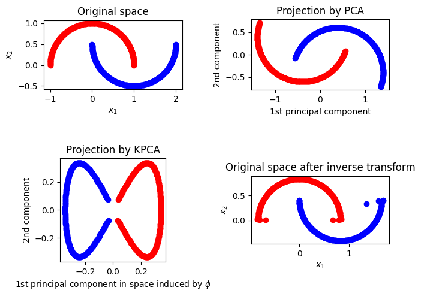

```python
Params_KPCA(X = X, kernel = "rbf", gamma = 20)
```

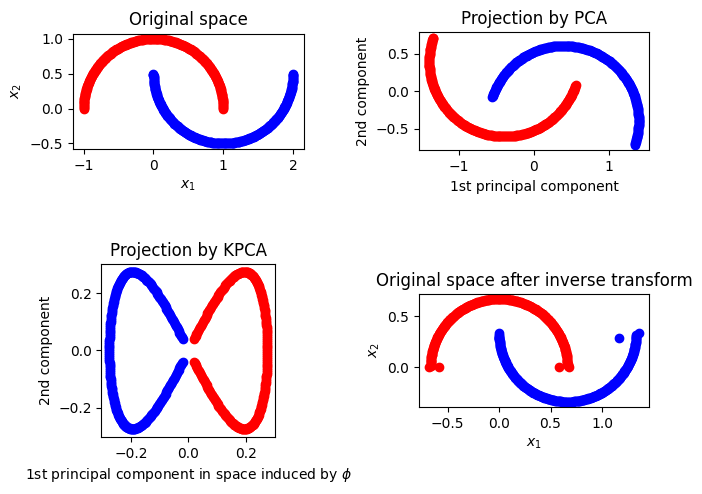

```python
Params_KPCA(X = X, kernel = "rbf", gamma = 50)
```

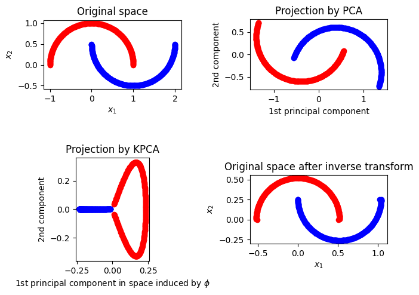

```python
Params_KPCA(X = X, kernel = "rbf", gamma = 100)
```

### Cambia el tipo de kernel y analiza los resultados. ¿Qué kernel funciona mejor?

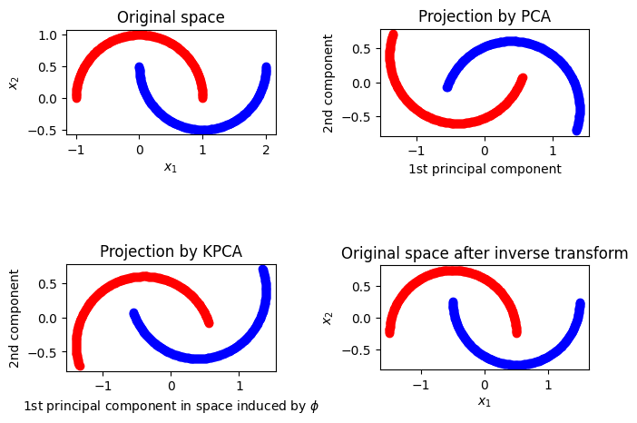

```python
Params_KPCA(X = X, kernel = "linear", gamma=4)
```

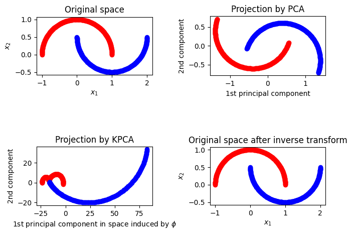

```python
Params_KPCA(X = X, kernel = "poly", gamma=5)
```

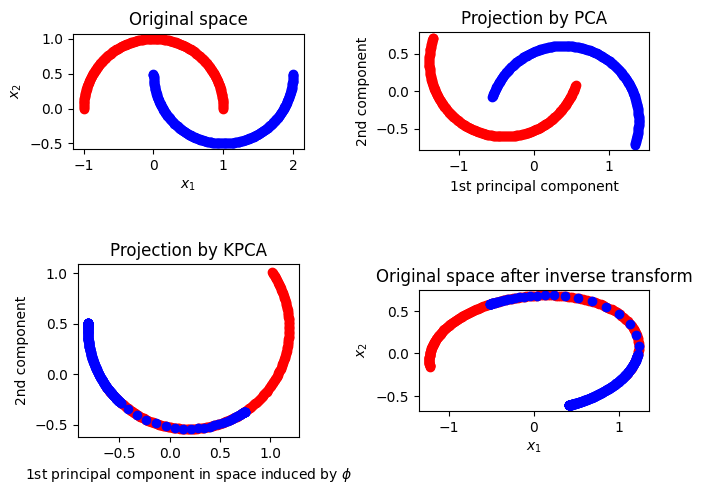

```python
Params_KPCA(X = X, kernel = "cosine", gamma=5)
```

Vemos como el mejor método con diferencia es el rbf, aun probando distintos gammas para los otros tipos de kernel, ninguno logra separar linealmente en el espacio de proyección los 2 clusters.

# Ahora con los círculos

```python
X, y = datasets.make_circles(n_samples=500, random_state=77, noise=0.05, factor=0.2)
```

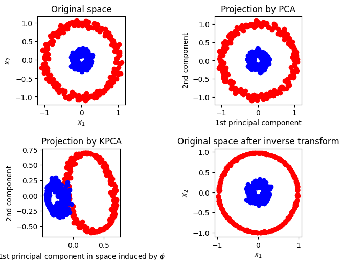

```python
Params_KPCA(X = X, kernel = "rbf", gamma = 1)
```

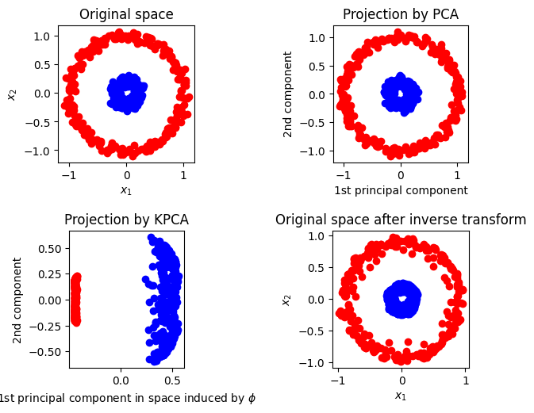

```python
Params_KPCA(X = X, kernel = "rbf", gamma = 5)
```

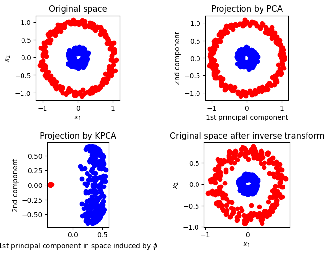

```python
Params_KPCA(X = X, kernel = "rbf", gamma = 10)
```

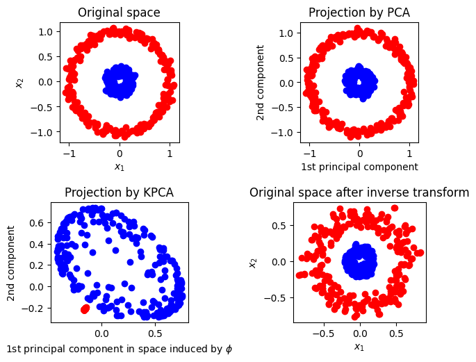

```python
Params_KPCA(X = X, kernel = "rbf", gamma = 20)
```

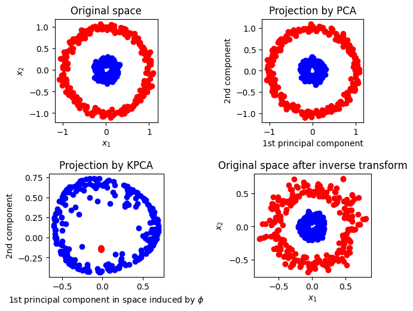

```python
Params_KPCA(X = X, kernel = "rbf", gamma = 25)
```

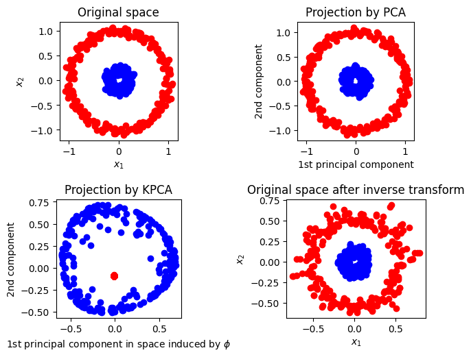

```python
Params_KPCA(X = X, kernel = "rbf", gamma = 30)
```

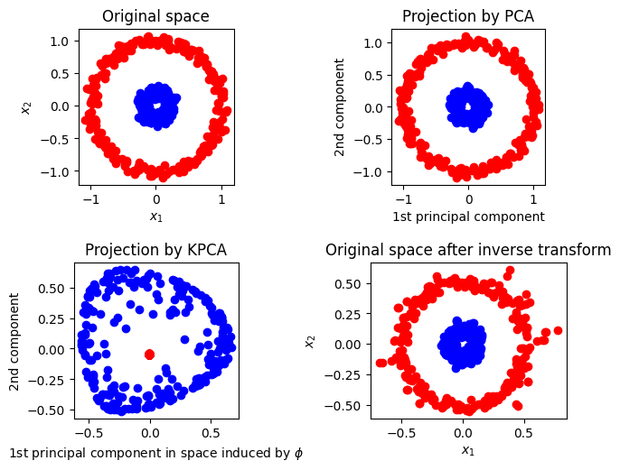

```python
Params_KPCA(X = X, kernel = "rbf", gamma = 50)
```

Para este caso, con gammas entre 5 y 10 es cuando funciona mejor el método para separar los 2 grupos.

### Cambia el tipo de kernel y analiza los resultados. ¿Qué kernel funciona mejor?

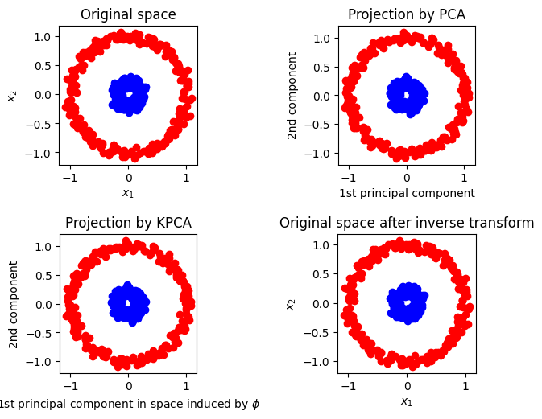

```python
Params_KPCA(X = X, kernel = "linear")
```

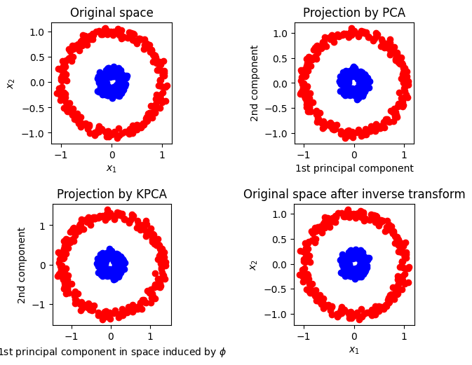

```python
Params_KPCA(X = X, kernel = "poly", gamma=None)
```

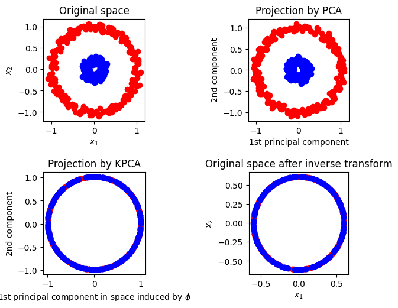

```python
Params_KPCA(X = X, kernel = "cosine")
```

Vemos cómo al ser la separación de un núcleo rodeado de puntos, kernels lineales, polinómicos o de cosenos no nos van a servir, al no ser el cluster apropiado para dichas funciones. El mejor con diferencia es el rbf.